# Residence time and microcystis

Rosie

2023-03-14

## Residence time data

```r
#Residence time from DSM2 models

library(tidyverse)
library(lubridate)
library(sf)
#read in the residence time data

res1 = read_csv("data/EX_2020_locRT.csv") %>%
  pivot_longer(cols = -SimPeriod, names_to = "Location", values_to = "ResTime") %>%
  mutate(Date = as.Date(SimPeriod, format = "%d%b%Y"), Region = str_extract(Location, "[A-Z]+" ))
```

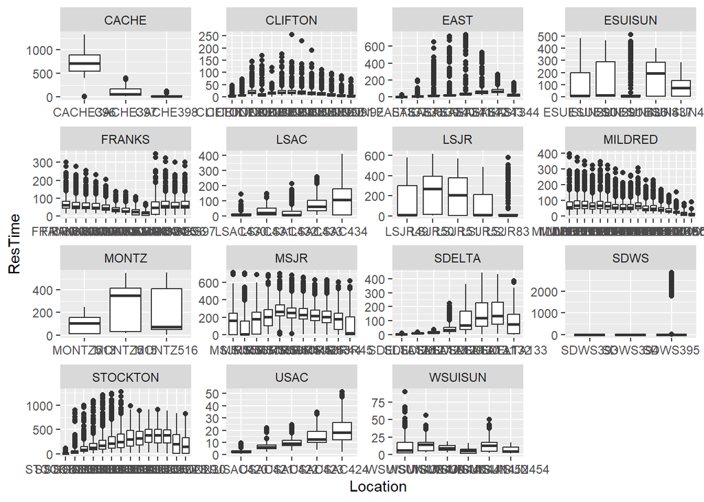

```r
ggplot(res1, aes(x = Location, y = ResTime)) + geom_boxplot()+facet_wrap(~Region, scales = "free")
```

OK, so most regions all have fairly similar residence times per reach. But let’s look at it by WYT just for funsies

```r
Yrs = read_csv("data/yearassignments.csv") %>%
  select(Year, Yr_type, Index)
#In other circumstances I'd merge these by water years, but the october of a year
#after a dry summer is probalby more like September of the same year than it is like February of the
#next year, so we'll go by calendar year instead.


res1 = mutate(res1, Month = month(Date), Year = year(Date)) %>%
  filter(Region != "SDWS") %>%
  left_join(Yrs)
```

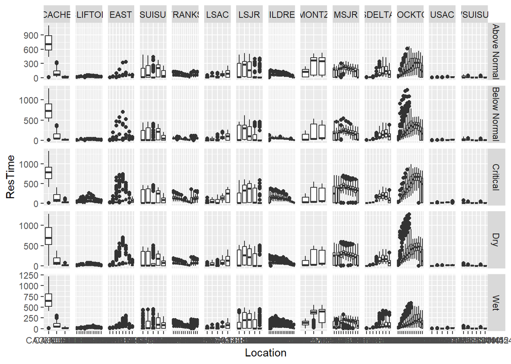

```r
ggplot(res1, aes(x = Location, y = ResTime)) + geom_boxplot()+
  facet_grid(Yr_type~Region, scales = "free")
```

OK, now let’s calculate averages by region

```r
resave = group_by(res1, SimPeriod, Region, Date, Yr_type, Month, Year, Index) %>%
  summarize(ResTime = mean(ResTime)) %>%
  mutate(DOY = yday(Date))
```

[output not shown]

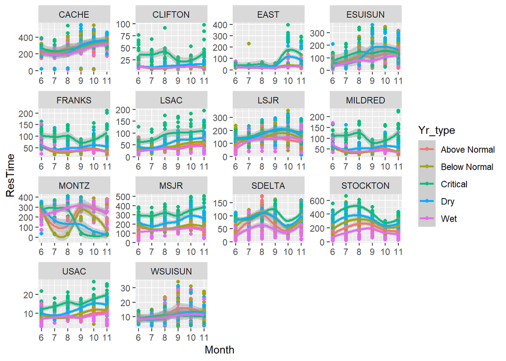

```r
ggplot(resave, aes(x = Month, y = ResTime, color = Yr_type)) + geom_point()+
  geom_smooth()+
  facet_wrap(~Region, scales = "free")
```

OK, now let’s merge the microcystis data onto the regions. but we need to think about how to do it. We’re trying to use microcystis from the whole time series, but it isn’t exactly the same years as the residence time modeling. I think the most logical thing is to average by month and water eyar type.

```r
HABregions15 = st_read("HABregions15.shp") %>%
  st_transform(crs = 4326) %>%
  st_make_valid()
#summarize residence time by water year type
resave2 = group_by(resave, Region, Yr_type, Month) %>%
  summarize(ResTime = mean(ResTime))  %>%
  rename(RegionDSM = Region)
#switch the names so they  match the other region names
reglook = read_csv("regionlookup.csv")
resave2 = left_join(resave2, reglook)
#load HABs data
load("data/HABs.RData")

#Make the data frame a sf object and join it to the regions
HABsReg = st_as_sf(filter(HABs, !is.na(Latitude)), coords = c("Longitude", "Latitude"), crs = 4326) %>%
  st_join(HABregions15) %>%
  mutate(Year = case_when(Source == "FMWTx" ~ 2021,
                          TRUE ~ Year)) %>%
  left_join(Yrs)
#join restime and HABs by region and water year type
HABrestime = left_join(HABsReg, resave2) %>%
  filter(!is.na(Microcystis), Source != "DOP", !is.na(Region), Month %in% c(6,7,8,9,10)) %>%
  mutate(Mic = factor(round(Microcystis), levels = c(1,2,3,4,5), labels = c("Absent", "Low", "Med", "High", "V.High")),
         Yr_type = factor(Yr_type, levels = c("Critical", "Dry", "Below Normal", "Above Normal", "Wet")))
```

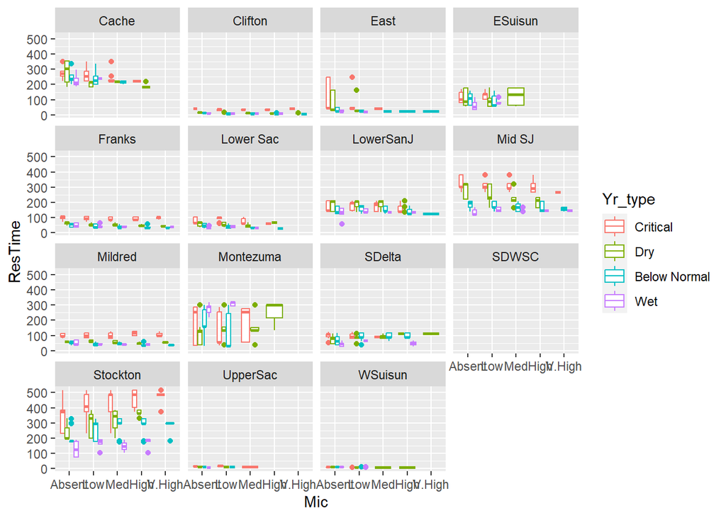

```r
#boxplot of residence time by microcystis scores
ggplot(HABrestime, aes(x =Mic, y = ResTime, color = Yr_type)) +
  geom_boxplot()+
  facet_wrap(~Region)
```

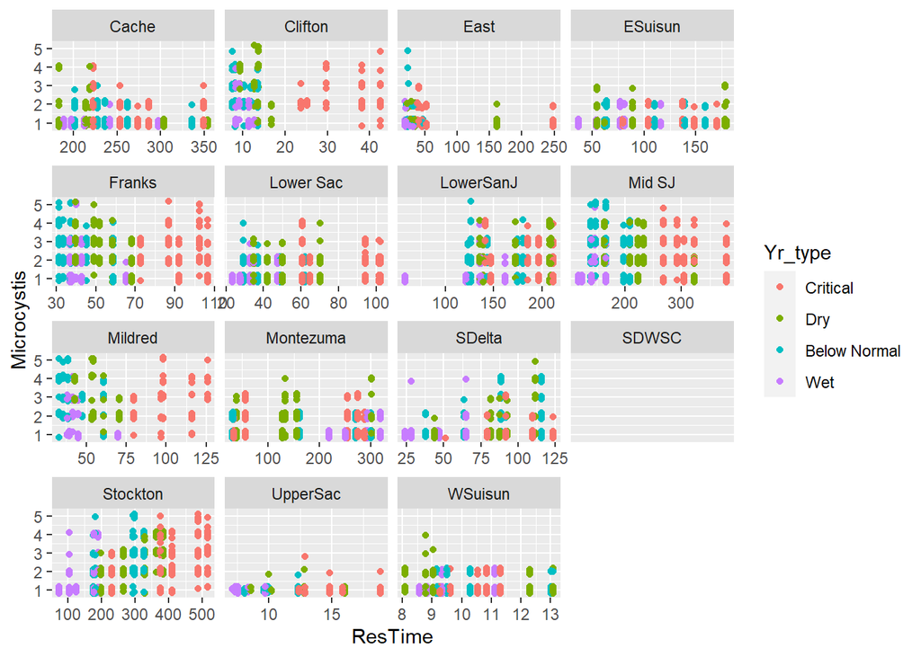

```r
#scatterplot of microcystis scores by residence time
ggplot(HABrestime, aes(x =ResTime, y = Microcystis, color = Yr_type)) +
  geom_point(position = "jitter")+
  facet_wrap(~Region, scales = "free_x")
```

OK, not let’s try everything together/

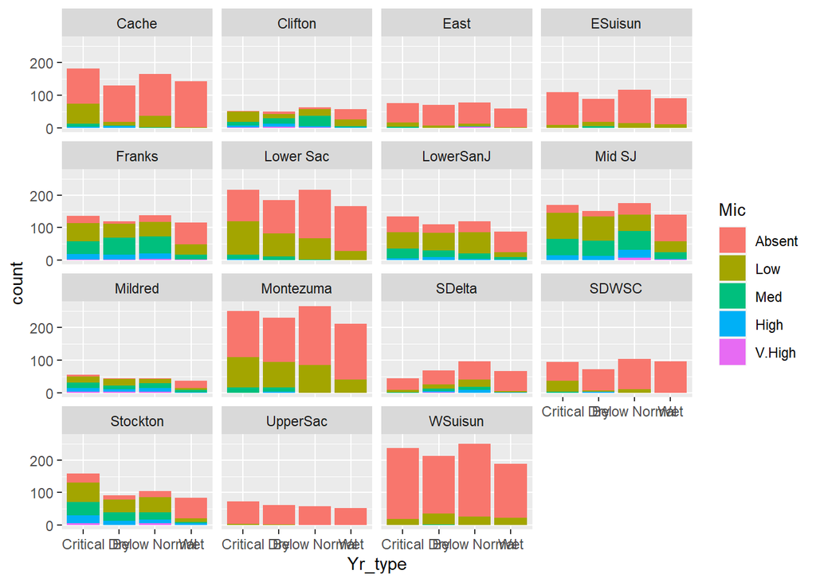

```r
#bar plot of frequency of microcystis by water year type and region
ggplot(HABrestime, aes(x =Yr_type, fill = Mic)) +
  geom_bar()+
  facet_wrap(~Region)
```

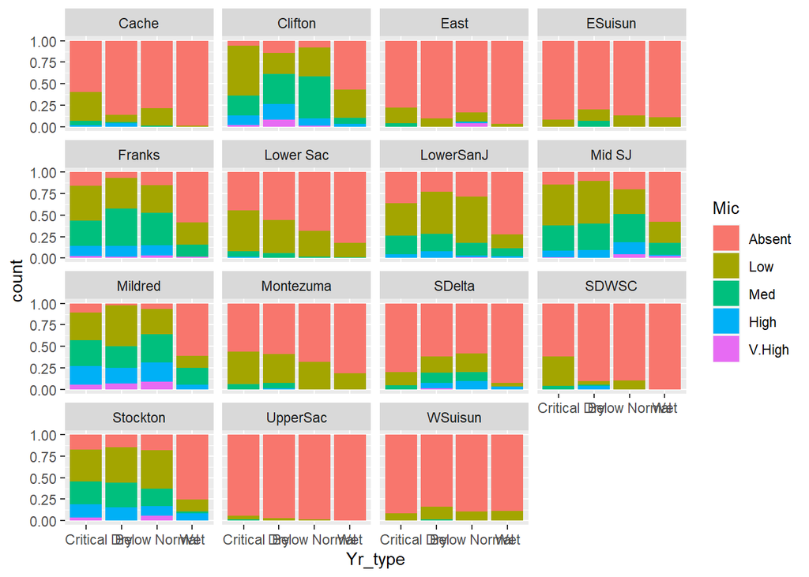

```r
#percentage version
ggplot(HABrestime, aes(x =Yr_type, fill = Mic)) +
  geom_bar(position = "fill")+
  facet_wrap(~Region)
```

OK, we see that drier year types have more Microcystis than wetter year types. Also a lot of variation across regions, with the central and south delta having the most

```r
#now maybe % microcystis by water year type?


HABRT2 = group_by(HABrestime, Yr_type, Region, Month) %>%
  summarise(Restime = mean(ResTime), n = n(), Mic0 = length(which(Mic == "Absent"))/n,
            MicLow = length(which(Mic %in% c("Low", "Med")))/n,
            MicHigh = length(which(Mic %in% c("High", "V.High")))/n)
```

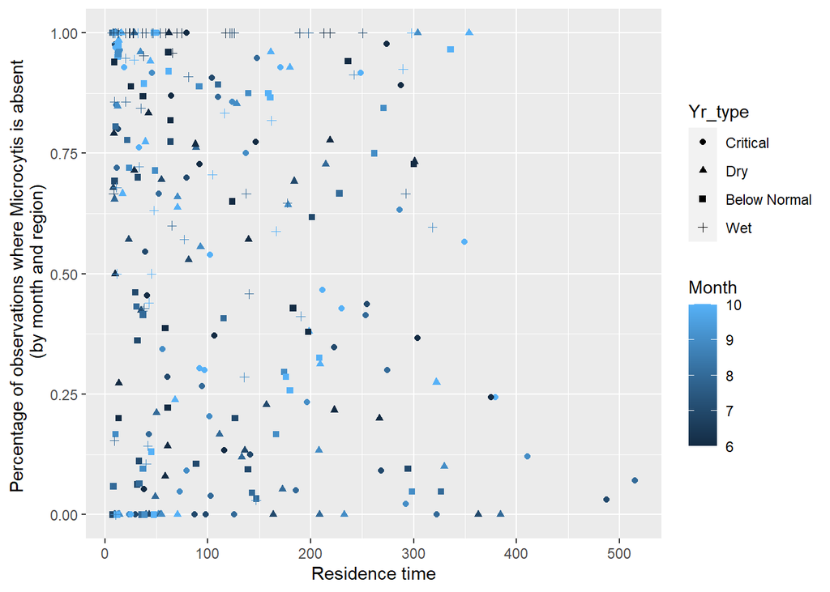

```r
#this is frequency of absence
ggplot(HABRT2, aes(x = Restime, y = Mic0, color = Month, shape = Yr_type))+
  geom_point()+ ylab("Percentage of observations where Microcytis is absent \n (by month and region)")+
  xlab("Residence time"
  )
```

We can see that most of the months that have 100% absence are in wet years. There aren’t as many patterns with month of the year as I was expecting, but it’s a bit hard to see. Also, the longest residence time months/regions have a lot of microcystis.

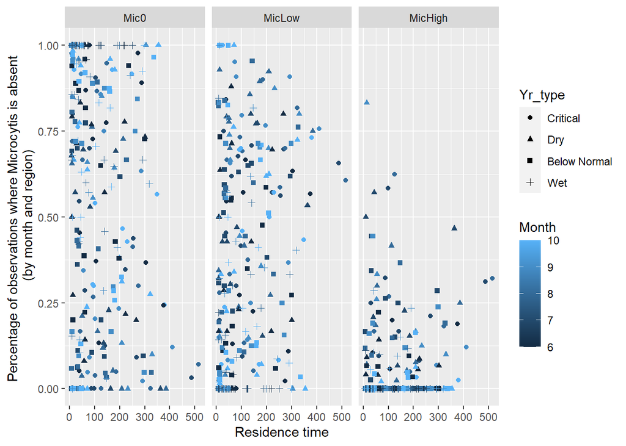

```r
#plot absence/presence/low all together?
HABRT3 = pivot_longer(HABRT2, cols = c(Mic0, MicLow, MicHigh), names_to = "MicLevel", values_to = "Percentage") %>%
  mutate(MicLevel = factor(MicLevel, levels = c("Mic0", "MicLow", "MicHigh")))

ggplot(HABRT3, aes(x = Restime, y = Percentage, color = Month, shape = Yr_type))+
  geom_point()+ ylab("Percentage of observations where Microcytis is absent \n (by month and region)")+
  xlab("Residence time"
  )+
  facet_wrap(~MicLevel)
```

OK, so maybe there is a pattern here? It’s honestly really hard to tell.

```r
library(ordinal)
library(effects)
library(MASS)
#Let's try a model of HABs versus temperature, and residence time
HABrestime = mutate(HABrestime, MicF = case_when(Microcystis ==1 ~ "Absent",
                                                 Microcystis %in% 2:3~ "Mid",
                                                 Microcystis %in% 4:5 ~ "High"),
                    MicF = factor(MicF, levels = c("Absent", "Mid", "High"), ordered = T))

#unfortunately, we are missing a lot of temperature  values
HABtest = filter(HABrestime,!is.na(Temperature), !is.na(ResTime), !is.na(Station), !is.na(MicF))


m1 = clmm(MicF ~ ResTime+ Temperature+  (1|Station)+ (1|Year), data = HABtest)

summary(m1)
```

```
## Cumulative Link Mixed Model fitted with the Laplace approximation
##
## formula: MicF ~ ResTime + Temperature + (1 | Station) + (1 | Year)
## data:    HABtest
##
##  link  threshold nobs logLik   AIC     niter      max.grad cond.H
##  logit flexible  6858 -4027.07 8066.15 1226(6152) 7.12e-02 2.2e+06
##
## Random effects:
##  Groups  Name        Variance Std.Dev.
##  Station (Intercept) 2.4926   1.5788
##  Year    (Intercept) 0.7943   0.8912
## Number of groups:  Station 173,  Year 16
##
## Coefficients:
##              Estimate Std. Error z value Pr(>|z|)
## ResTime     0.0007814  0.0004810   1.625    0.104
## Temperature 0.3525317  0.0183471  19.215   <2e-16 ***
## ---
## Signif. codes:  0 '***' 0.001 '**' 0.01 '*' 0.05 '.' 0.1 ' ' 1
##
## Threshold coefficients:
##            Estimate Std. Error z value
## Absent|Mid   8.2319     0.4719   17.45
## Mid|High    12.2157     0.4952   24.67
```

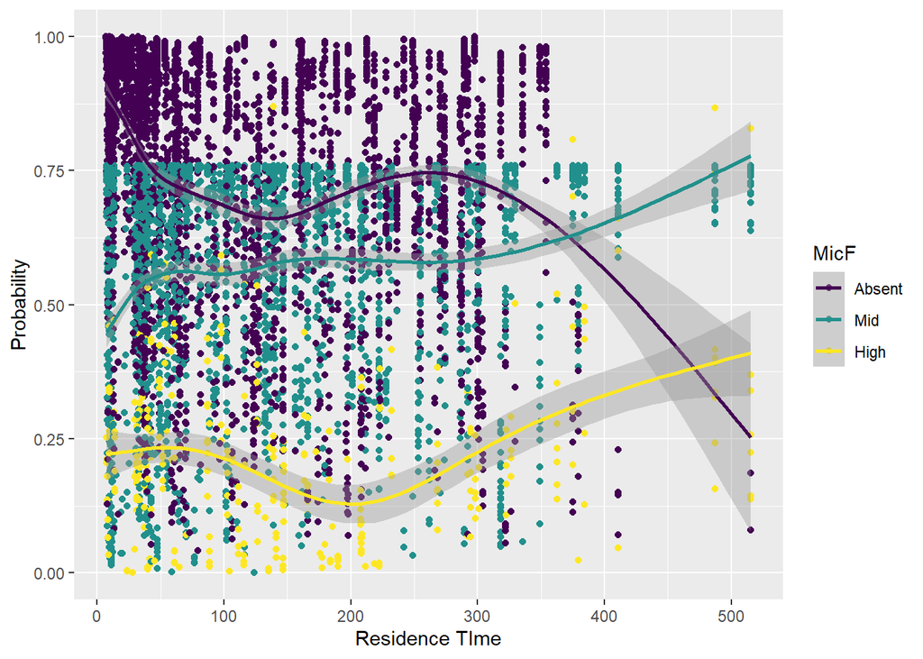

```r
#not as exciting as I'd think
#Also, i need to work on how to plot this.

HABtest$fits = fitted(m1)

ggplot(HABtest, aes( ResTime, fits, color = MicF))+ geom_point()+ geom_smooth()+
  ylab("Probability")+ xlab("Residence TIme")
```

```r
#well, that's a mess
```

## Dry years only

```r
#maybe if we standardized by water year type in some way?
#Let's try just dry and critical years

dry = filter(HABtest, Yr_type %in% c("Dry", "Critical"))

m1 = clmm(MicF ~ ResTime+ Temperature+ Month+  (1|Station)+ (1|Year), data = dry)

summary(m1)
```

```
## Cumulative Link Mixed Model fitted with the Laplace approximation
##
## formula: MicF ~ ResTime + Temperature + Month + (1 | Station) + (1 | Year)
## data:    dry
##
##  link  threshold nobs logLik   AIC     niter     max.grad cond.H
##  logit flexible  3468 -2057.43 4128.85 361(1743) 3.52e-02 3.6e+06
##
## Random effects:
##  Groups  Name        Variance Std.Dev.
##  Station (Intercept) 3.1816   1.7837
##  Year    (Intercept) 0.2593   0.5092
## Number of groups:  Station 168,  Year 9
##
## Coefficients:
##              Estimate Std. Error z value Pr(>|z|)
## ResTime     0.0013879  0.0007416   1.872   0.0613 .
## Temperature 0.5651023  0.0296579  19.054  < 2e-16 ***
## Month       0.3089884  0.0391805   7.886 3.11e-15 ***
## ---
## Signif. codes:  0 '***' 0.001 '**' 0.01 '*' 0.05 '.' 0.1 ' ' 1
##
## Threshold coefficients:
##            Estimate Std. Error z value
## Absent|Mid  15.2561     0.8617   17.70
## Mid|High    19.9595     0.9171   21.76
```

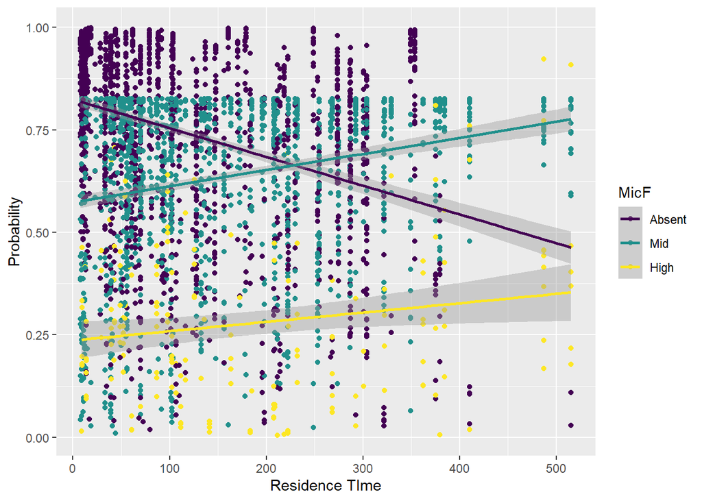

```r
#not as exciting as I'd think
#Also, i need to work on how to plot this.

dry$fits = fitted(m1)

ggplot(dry, aes( ResTime, fits, color = MicF))+ geom_point()+ geom_smooth(method = "lm")+
  ylab("Probability")+ xlab("Residence TIme")
```

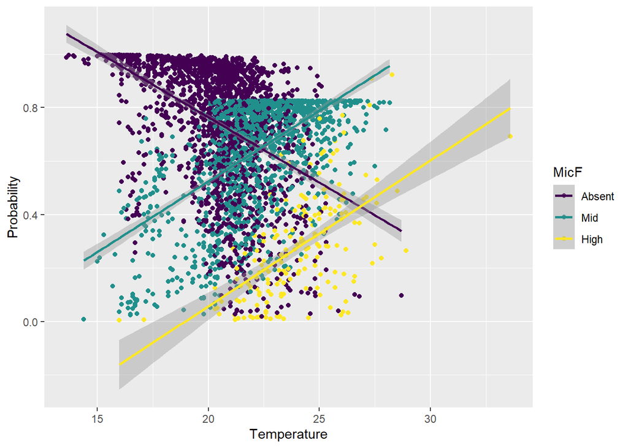

```r
ggplot(dry, aes(Temperature, fits, color = MicF))+ geom_point()+ geom_smooth(method = "lm")+
  ylab("Probability")+ xlab("Temperature")
```

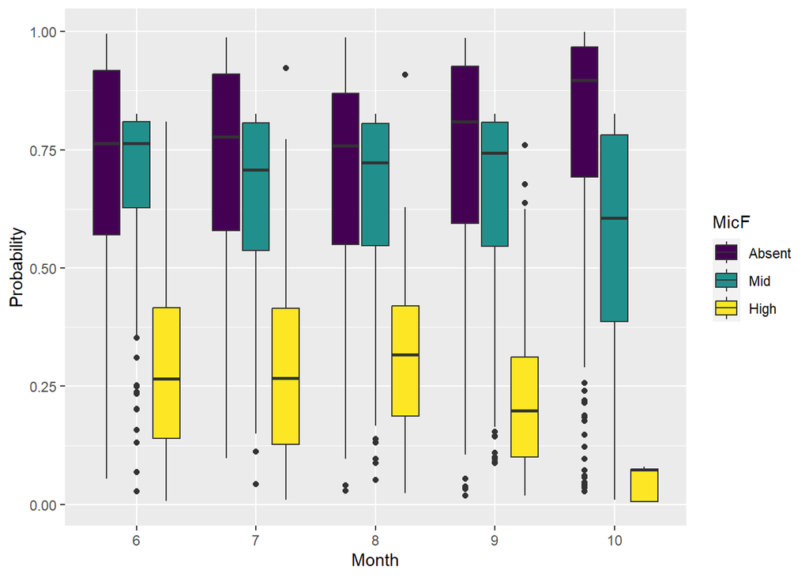

```r
ggplot(dry, aes(as.factor(Month), fits, fill = MicF))+ geom_boxplot()+
  ylab("Probability")+ xlab("Month")
```

```r
#It's definitely better with Month in there
```

what if we did a binomial model by region?

```r
micbin = group_by(dry, Region, Year) %>%
  summarize(Present = length(Microcystis[which(Microcystis>1)]), Absent = length(Microcystis[which(Microcystis==1)]),
            ResTime = mean(ResTime), Temperature = mean(Temperature, na.rm =T), Salinity = mean(Salinity, na.rm = T))
```

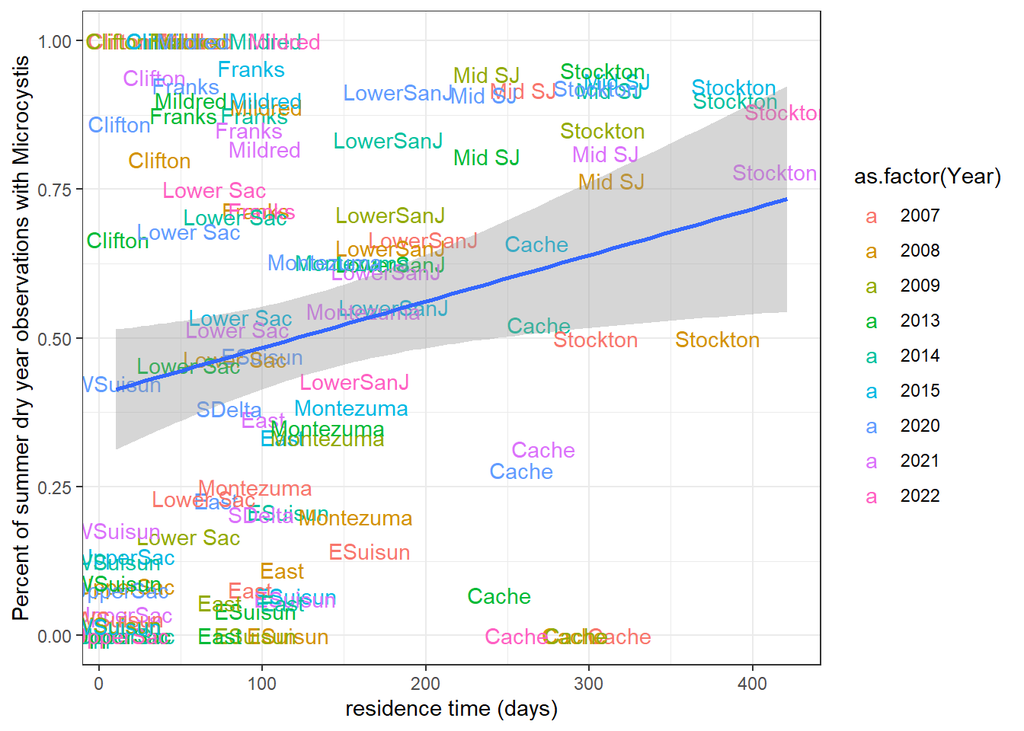

```r
ggplot(micbin, aes(x = ResTime, y = Present/(Present+Absent))) + geom_text(aes(label = Region, color = as.factor(Year)))+
  ylab("Percent of summer dry year observations with Microcystis")+ xlab("residence time (days)")+
  geom_smooth(method = "lm")+ theme_bw()
```

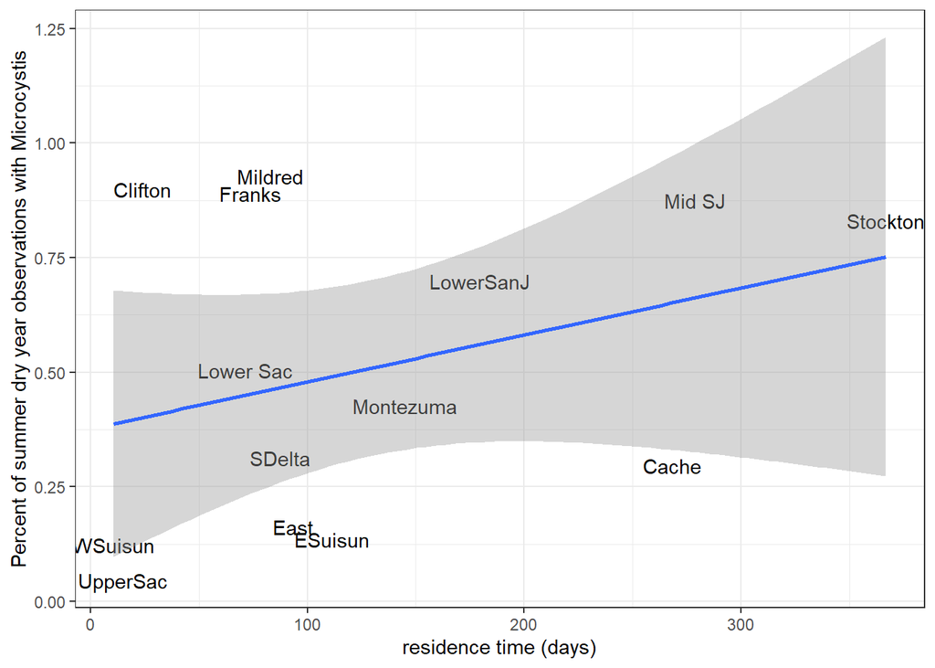

```r
micbin2 = group_by(dry, Region) %>%
  summarize(Present = length(Microcystis[which(Microcystis>1)]), Absent = length(Microcystis[which(Microcystis==1)]),
            ResTime = mean(ResTime), Temperature = mean(Temperature, na.rm =T), Salinity = mean(Salinity, na.rm = T))

ggplot(micbin2, aes(x = ResTime, y = Present/(Present+Absent))) + geom_text(aes(label = Region))+
  ylab("Percent of summer dry year observations with Microcystis")+ xlab("residence time (days)")+
  geom_smooth(method = "lm")+ theme_bw()
```

I don’t hate this.

```r
library(lme4)
library(lmerTest)
bn1 = glm(cbind(Present, Absent)~ Temperature + ResTime+ Salinity + Year, data = micbin, family = "binomial")
summary(bn1)
```

```
##
## Call:
## glm(formula = cbind(Present, Absent) ~ Temperature + ResTime +
##     Salinity + Year, family = "binomial", data = micbin)
##
## Deviance Residuals:
##     Min       1Q   Median       3Q      Max
## -7.6935  -2.5400   0.0298   2.2991   5.2385
##
## Coefficients:
##               Estimate Std. Error z value Pr(>|z|)
## (Intercept) 11.9660841 18.9141708   0.633    0.527
## Temperature  0.6245674  0.0412776  15.131  < 2e-16 ***
## ResTime      0.0018554  0.0004382   4.235 2.29e-05 ***
## Salinity    -0.0827262  0.0120274  -6.878 6.06e-12 ***
## Year        -0.0125827  0.0096086  -1.310    0.190
## ---
## Signif. codes:  0 '***' 0.001 '**' 0.01 '*' 0.05 '.' 0.1 ' ' 1
##
## (Dispersion parameter for binomial family taken to be 1)
##
##     Null deviance: 1739.68  on 109  degrees of freedom
## Residual deviance:  952.62  on 105  degrees of freedom
##   (3 observations deleted due to missingness)
## AIC: 1237.7
##
## Number of Fisher Scoring iterations: 5
```

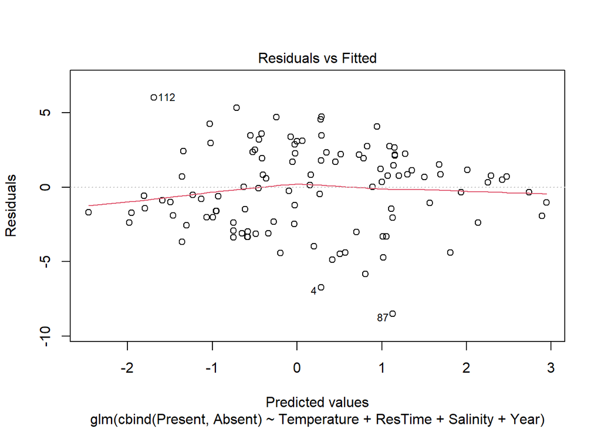

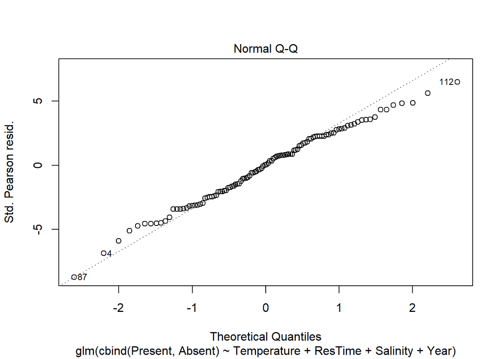

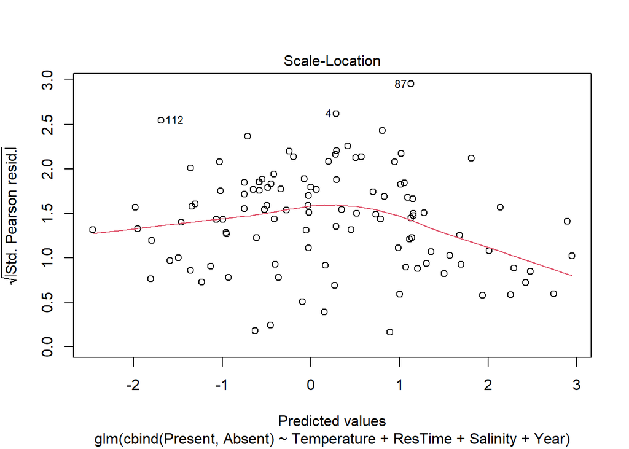

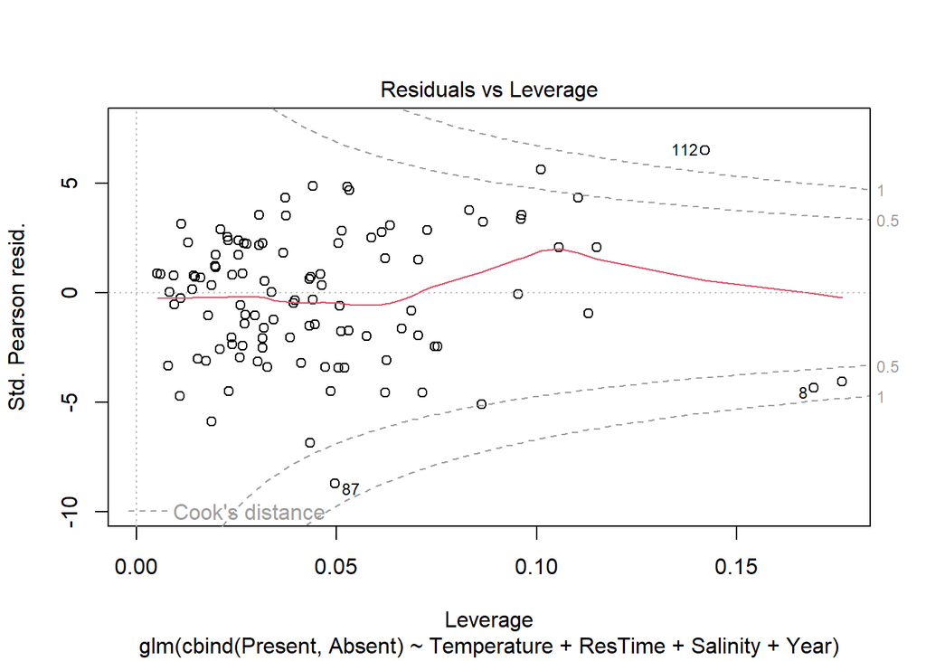

```r
plot(bn1)
```

```r
micbin = mutate(micbin, Year2 = Year-2000, Temp = scale(Temperature), Res = scale(ResTime), Salinity = scale(Salinity))
bn2 = glmer(cbind(Present, Absent)~ Temp + Res+ Salinity + (1|Year2), data = micbin, family = "binomial")
bn2.1 = glmer(cbind(Present, Absent)~ Temp + log(ResTime)+ Salinity + (1|Year2) + (1|Region), data = micbin, family = "binomial")
#bn2 = glm(cbind(Present, Absent)~ Temp + Res+ Salinity + Year2, data = micbin, family = "binomial")
summary(bn2)
```

```
## Generalized linear mixed model fit by maximum likelihood (Laplace
##   Approximation) [glmerMod]
##  Family: binomial  ( logit )
## Formula: cbind(Present, Absent) ~ Temp + Res + Salinity + (1 | Year2)
##    Data: micbin
##
##      AIC      BIC   logLik deviance df.resid
##   1855.6   1869.1   -922.8   1845.6      105
##
## Scaled residuals:
##     Min      1Q  Median      3Q     Max
## -7.3048 -2.9809  0.6203  3.0833  7.1284
##
## Random effects:
##  Groups Name        Variance Std.Dev.
##  Year2  (Intercept) 0.1507   0.3882
## Number of obs: 110, groups:  Year2, 9
##
## Fixed effects:
##             Estimate Std. Error z value Pr(>|z|)
## (Intercept) -0.09272    0.13625  -0.680  0.49619
## Temp         0.16397    0.08787   1.866  0.06204 .
## Res          0.16907    0.05171   3.270  0.00108 **
## Salinity     0.09525    0.05396   1.765  0.07753 .
## ---
## Signif. codes:  0 '***' 0.001 '**' 0.01 '*' 0.05 '.' 0.1 ' ' 1
##
## Correlation of Fixed Effects:
##          (Intr) Temp   Res
## Temp     -0.050
## Res      -0.013 -0.048
## Salinity  0.012 -0.253 -0.078
```

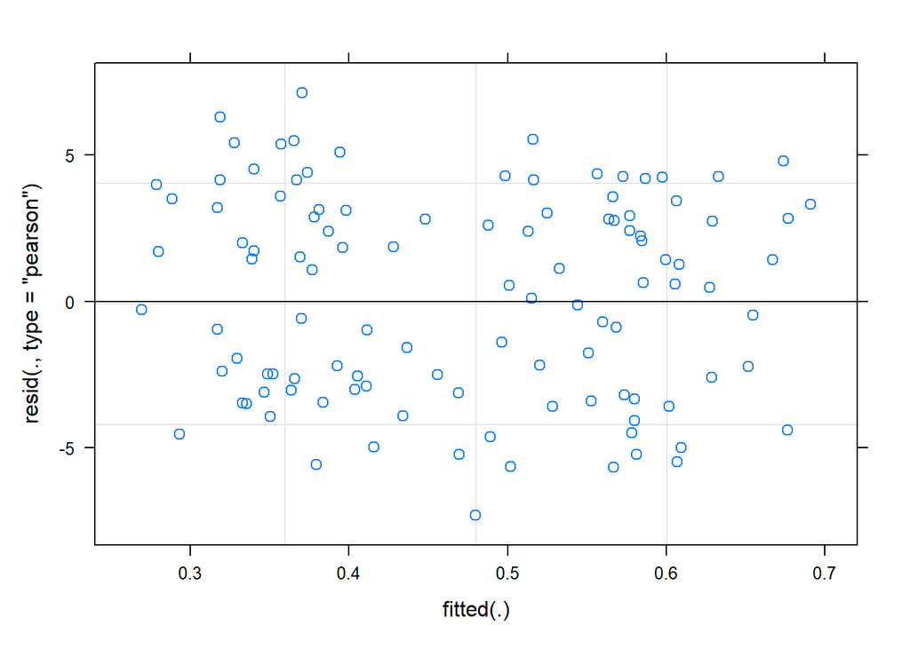

```r
plot(bn2)
```

```r
summary(bn2.1)
```

```
## Generalized linear mixed model fit by maximum likelihood (Laplace
##   Approximation) [glmerMod]
##  Family: binomial  ( logit )
## Formula: cbind(Present, Absent) ~ Temp + log(ResTime) + Salinity + (1 |
##     Year2) + (1 | Region)
##    Data: micbin
##
##      AIC      BIC   logLik deviance df.resid
##    604.8    621.0   -296.4    592.8      104
##
## Scaled residuals:
##     Min      1Q  Median      3Q     Max
## -2.9401 -0.9742 -0.1574  0.7319  4.5496
##
## Random effects:
##  Groups Name        Variance Std.Dev.
##  Region (Intercept) 3.0600   1.7493
##  Year2  (Intercept) 0.1745   0.4178
## Number of obs: 110, groups:  Region, 14; Year2, 9
##
## Fixed effects:
##              Estimate Std. Error z value Pr(>|z|)
## (Intercept)  -2.70286    1.36551  -1.979 0.047773 *
## Temp          0.44548    0.11758   3.789 0.000151 ***
## log(ResTime)  0.58128    0.28708   2.025 0.042884 *
## Salinity     -0.22488    0.08155  -2.757 0.005826 **
## ---
## Signif. codes:  0 '***' 0.001 '**' 0.01 '*' 0.05 '.' 0.1 ' ' 1
##
## Correlation of Fixed Effects:
##             (Intr) Temp   lg(RT)
## Temp         0.098
## log(ResTim) -0.933 -0.103
## Salinity     0.012 -0.279 -0.010
```

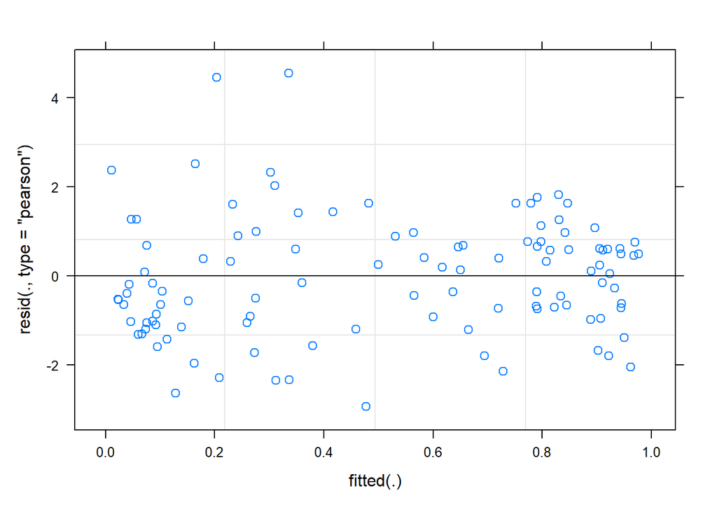

```r
plot(bn2.1)
```

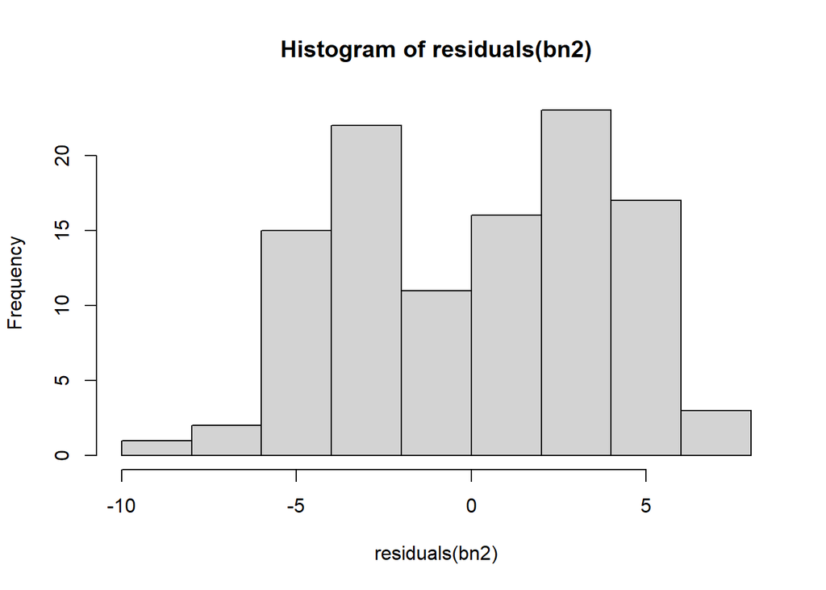

```r
hist(residuals(bn2))
```

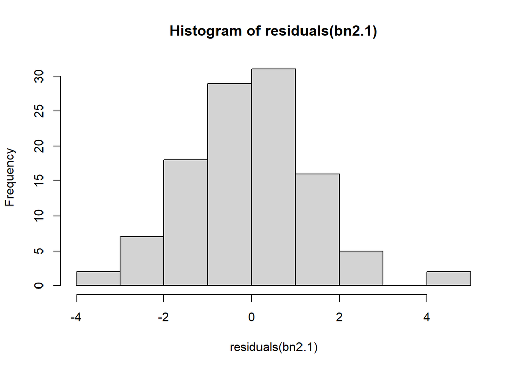

```r
hist(residuals(bn2.1))
```

```r
#OK, better!
```

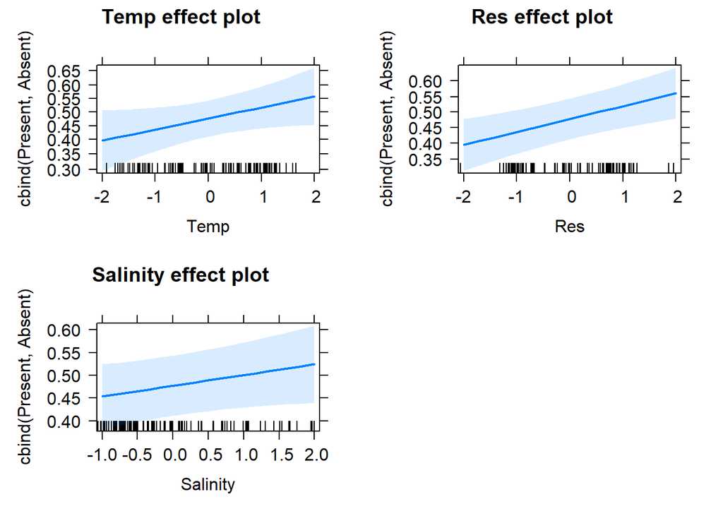

```r
library(effects)
plot(allEffects(bn2))
```

```r
library(DHARMa)
```

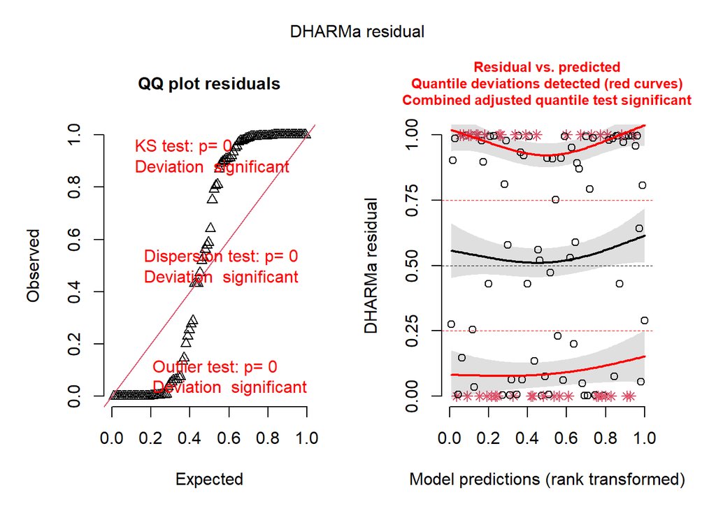

```r
res = simulateResiduals(bn2)
plot(res)
```

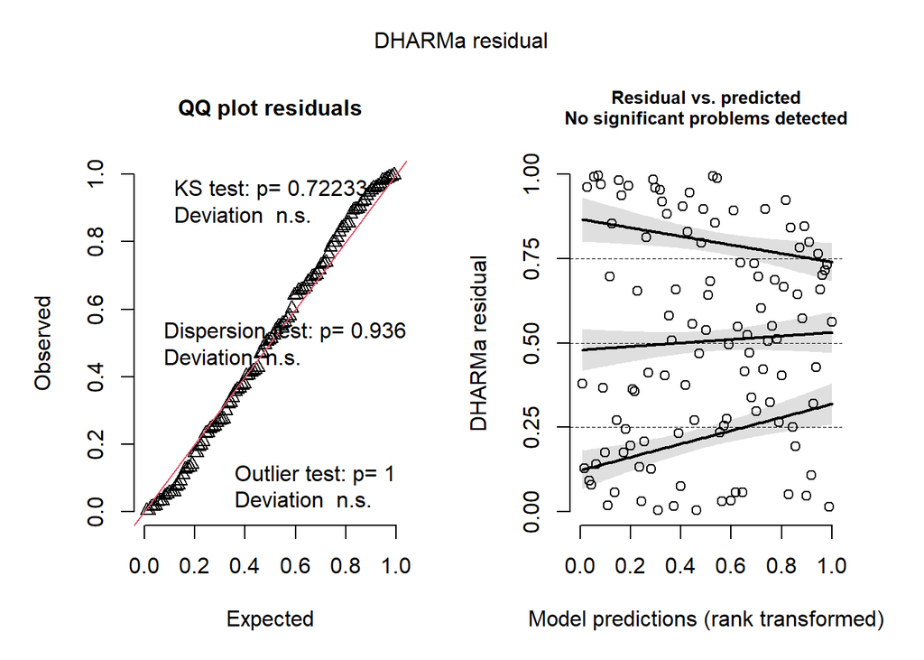

```r
res2 = simulateResiduals(bn2.1)
plot(res2)
```

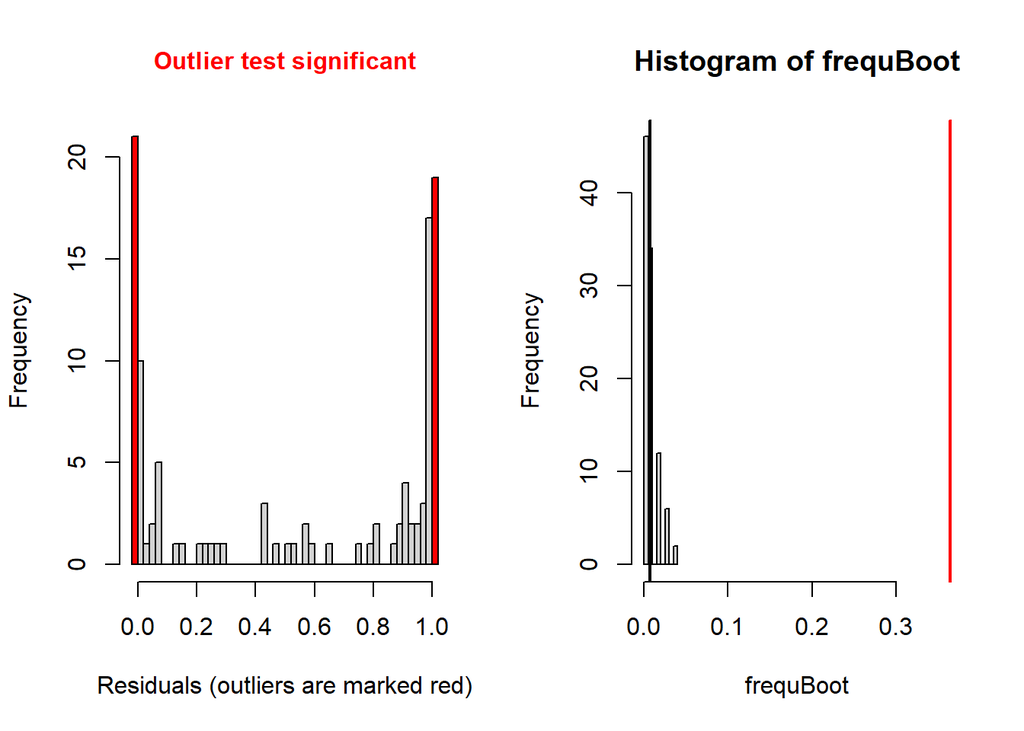

```
##
##  DHARMa bootstrapped outlier test
##
## data:  bn2
## outliers at both margin(s) = 40, observations = 110, p-value < 2.2e-16
## alternative hypothesis: two.sided
##  percent confidence interval:
##  0.00000000 0.02727273
## sample estimates:
## outlier frequency (expected: 0.00763636363636364 )
##                                          0.3636364
```

```r
#Ok, that is definitely not good

testOutliers(bn2)
```

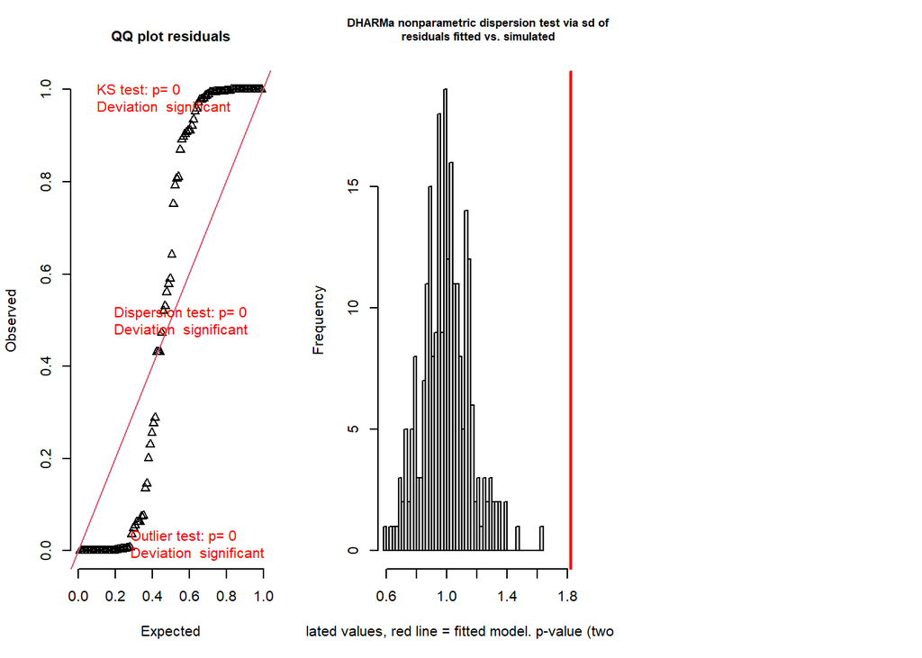

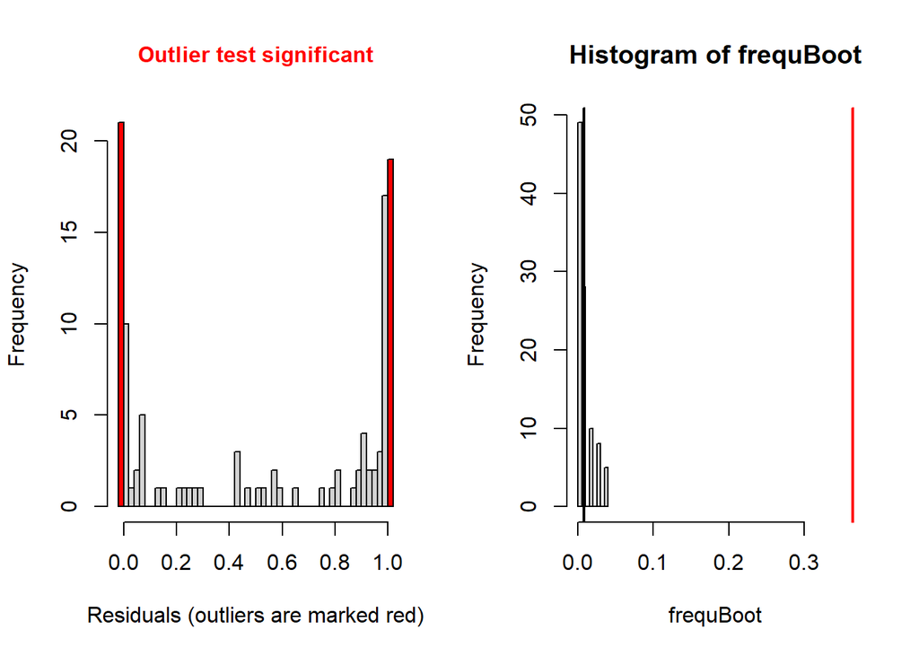

```
## $uniformity
##
##  Asymptotic one-sample Kolmogorov-Smirnov test
##
## data:  simulationOutput$scaledResiduals
## D = 0.33745, p-value = 2.635e-11
## alternative hypothesis: two-sided
##
##
## $dispersion
##
##  DHARMa nonparametric dispersion test via sd of residuals fitted vs.
##  simulated
##
## data:  simulationOutput
## dispersion = 1.825, p-value < 2.2e-16
## alternative hypothesis: two.sided
##
##
## $outliers
##
##  DHARMa bootstrapped outlier test
##
## data:  simulationOutput
## outliers at both margin(s) = 40, observations = 110, p-value < 2.2e-16
## alternative hypothesis: two.sided
##  percent confidence interval:
##  0.00000000 0.03636364
## sample estimates:
## outlier frequency (expected: 0.00836363636363636 )
##                                          0.3636364
```

```
## $uniformity
##
##  Asymptotic one-sample Kolmogorov-Smirnov test
##
## data:  simulationOutput$scaledResiduals
## D = 0.33745, p-value = 2.635e-11
## alternative hypothesis: two-sided
##
##
## $dispersion
##
##  DHARMa nonparametric dispersion test via sd of residuals fitted vs.
##  simulated
##
## data:  simulationOutput
## dispersion = 1.825, p-value < 2.2e-16
## alternative hypothesis: two.sided
##
##
## $outliers
##
##  DHARMa bootstrapped outlier test
##
## data:  simulationOutput
## outliers at both margin(s) = 40, observations = 110, p-value < 2.2e-16
## alternative hypothesis: two.sided
##  percent confidence interval:
##  0.00000000 0.03636364
## sample estimates:
## outlier frequency (expected: 0.00836363636363636 )
##                                          0.3636364
```

```r
testResiduals(res)
```

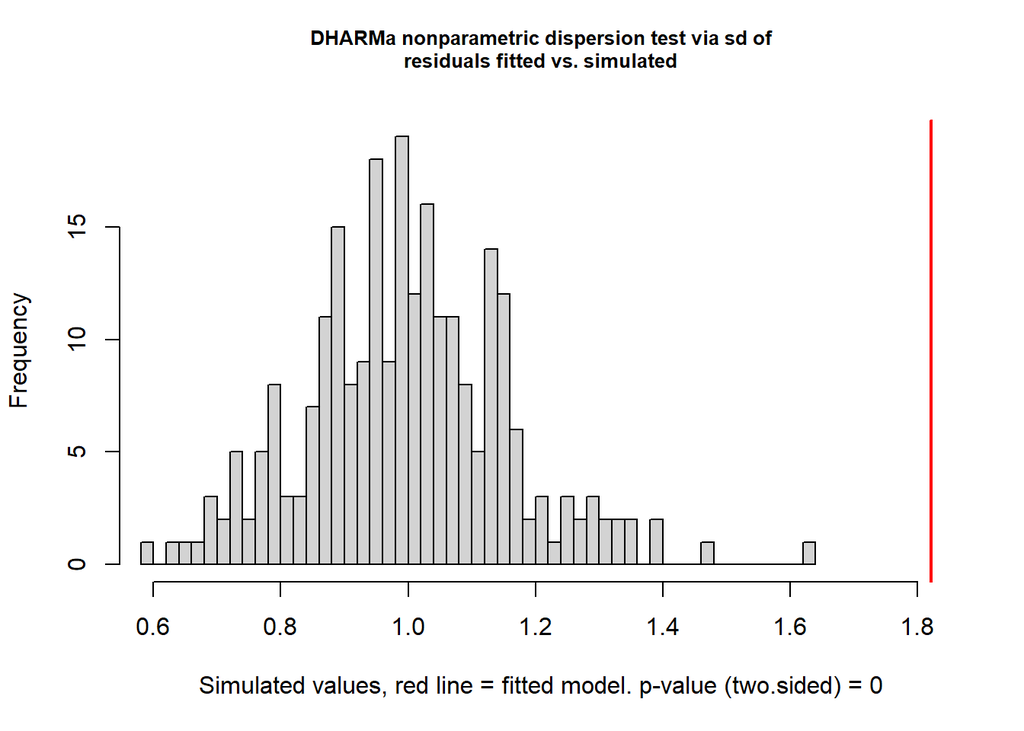

```
##
##  DHARMa nonparametric dispersion test via sd of residuals fitted vs.
##  simulated
##
## data:  simulationOutput
## dispersion = 1.825, p-value < 2.2e-16
## alternative hypothesis: two.sided
```

```r
testDispersion(res)
```

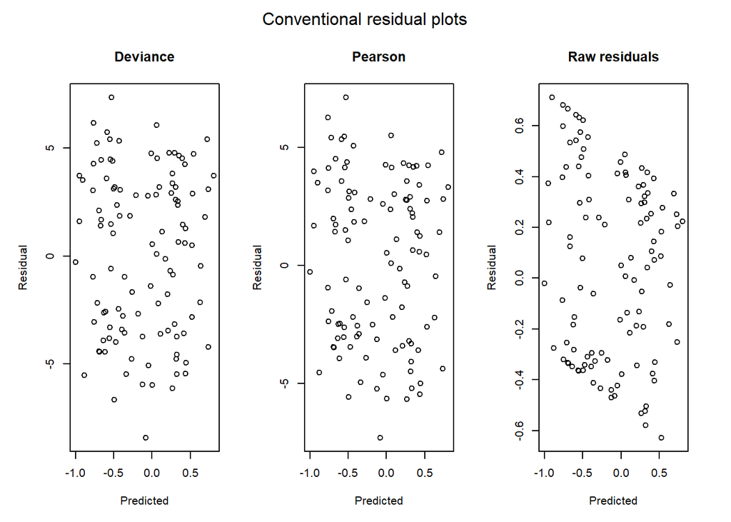

```r
plotConventionalResiduals(bn2)
```

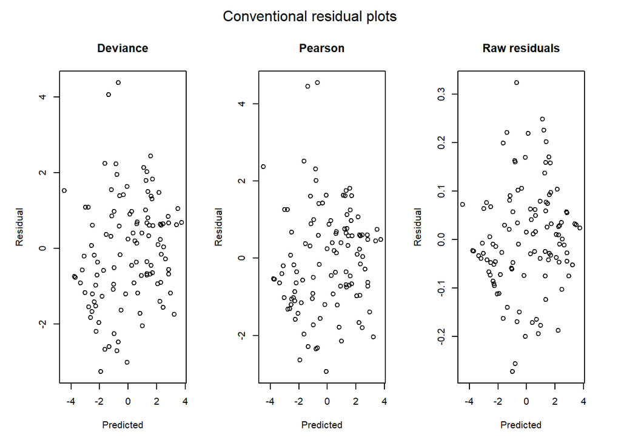

```r
plotConventionalResiduals(bn2.1)
```